# Assignment 1: PyTorch Basics

## Part B-3. Optimization Parameters

For this section, we will work with `large_net` only.

### Part B-3(i) [0.5pt EXPLORATORY]

Train `large_net` with all default parameters, except set `learning_rate=0.001`. Does the model take longer/shorter to train? Plot the training curve. Describe the effect of *lowering* the learning rate.

```python
# Note: When we re-construct the model, we start the training
# with *random weights*. If we omit this code, the values of
# the weights will still be the previously trained values.
large_net = LargeNet()
```

```
Training LargeNet with learning_rate=0.001...
Using device: cuda
Epoch 1: Train err: 0.8194, Train loss: 1.9469 | Validation err: 0.8042, Validation loss: 1.9318
Epoch 2: Train err: 0.7798, Train loss: 1.9226 | Validation err: 0.7698, Validation loss: 1.8971
Epoch 3: Train err: 0.7712, Train loss: 1.8729 | Validation err: 0.7196, Validation loss: 1.8306
Epoch 4: Train err: 0.7183, Train loss: 1.7978 | Validation err: 0.6958, Validation loss: 1.7383
Epoch 5: Train err: 0.6620, Train loss: 1.7188 | Validation err: 0.6587, Validation loss: 1.6580
Epoch 6: Train err: 0.6204, Train loss: 1.6462 | Validation err: 0.6534, Validation loss: 1.6264
Epoch 7: Train err: 0.5985, Train loss: 1.5939 | Validation err: 0.6587, Validation loss: 1.6043
Epoch 8: Train err: 0.5833, Train loss: 1.5454 | Validation err: 0.5820, Validation loss: 1.5294
Epoch 9: Train err: 0.5582, Train loss: 1.4850 | Validation err: 0.6164, Validation loss: 1.5224
Epoch 10: Train err: 0.5489, Train loss: 1.4318 | Validation err: 0.5979, Validation loss: 1.5393
Epoch 11: Train err: 0.5443, Train loss: 1.4095 | Validation err: 0.5370, Validation loss: 1.4424
Epoch 12: Train err: 0.5139, Train loss: 1.3786 | Validation err: 0.5873, Validation loss: 1.4945
Epoch 13: Train err: 0.5112, Train loss: 1.3342 | Validation err: 0.4788, Validation loss: 1.4092
Epoch 14: Train err: 0.4716, Train loss: 1.2567 | Validation err: 0.5000, Validation loss: 1.3648
Epoch 15: Train err: 0.4411, Train loss: 1.1856 | Validation err: 0.5159, Validation loss: 1.3644
Epoch 16: Train err: 0.4246, Train loss: 1.1614 | Validation err: 0.5317, Validation loss: 1.3960
Epoch 17: Train err: 0.4114, Train loss: 1.1180 | Validation err: 0.5185, Validation loss: 1.4537
Epoch 18: Train err: 0.4028, Train loss: 1.0958 | Validation err: 0.5397, Validation loss: 1.4306
Epoch 19: Train err: 0.3882, Train loss: 1.0794 | Validation err: 0.4947, Validation loss: 1.3675
Epoch 20: Train err: 0.3737, Train loss: 1.0332 | Validation err: 0.5503, Validation loss: 1.4553
Epoch 21: Train err: 0.3591, Train loss: 0.9874 | Validation err: 0.5026, Validation loss: 1.4012
Epoch 22: Train err: 0.3221, Train loss: 0.9181 | Validation err: 0.4868, Validation loss: 1.3895
Epoch 23: Train err: 0.3148, Train loss: 0.9075 | Validation err: 0.5000, Validation loss: 1.4718
Epoch 24: Train err: 0.3280, Train loss: 0.9131 | Validation err: 0.5265, Validation loss: 1.4407
Epoch 25: Train err: 0.2851, Train loss: 0.8494 | Validation err: 0.5026, Validation loss: 1.4683
Epoch 26: Train err: 0.2996, Train loss: 0.8455 | Validation err: 0.5106, Validation loss: 1.4420
Epoch 27: Train err: 0.2639, Train loss: 0.7704 | Validation err: 0.5053, Validation loss: 1.5340
Epoch 28: Train err: 0.2956, Train loss: 0.7952 | Validation err: 0.5265, Validation loss: 1.7168
Epoch 29: Train err: 0.2679, Train loss: 0.7761 | Validation err: 0.5000, Validation loss: 1.4479
Epoch 30: Train err: 0.2143, Train loss: 0.6549 | Validation err: 0.4841, Validation loss: 1.4886
Finished Training
Total time elapsed: 271.12 seconds

LargeNet (lr=0.001) Training Curves:
```

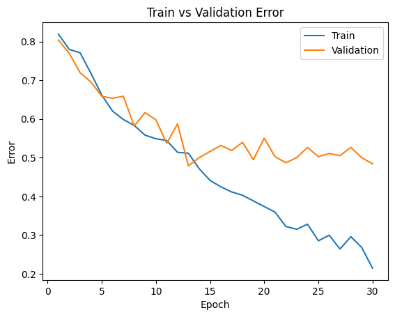

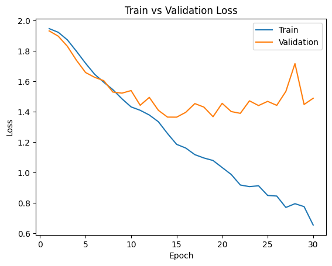

```python
# TO BE COMPLETED

# Reset the model to start with random weights
large_net = LargeNet()

# Train with lower learning rate
print("Training LargeNet with learning_rate=0.001...")
train_net(large_net, learning_rate=0.001)


# Plot training curves
print("\nLargeNet (lr=0.001) Training Curves:")
model_path = get_model_name("large", batch_size=64, learning_rate=0.001, epoch=29)
model_path = os.path.join(save_dir, model_path)
plot_training_curve(model_path)
```

```python
'''
PROVIDE YOUR ANSWER BELOW

When the learning rate is set to be 0.001, and we keep the model running on cuda GPU.

The training time (271.12 seconds) is longer than before.
The previous condition contained learning_rate as 0.01 and training time as 260.73 seconds.

From this observation, it seems like that the learning rate does not significantly change the amount of computation per epoch,
so the small difference is likely due to run-to-run variation rather than learning rate itself.

When we set smaller learning rate, this can lead to slower convergence. From the graph we can see training error decreases gradually
and remains relatively high at the end, whereas with lr=0.01 the training error approached 0.

Since we see such a pattern, it could also suggest that the model is reducing the overfitting pattern as well.
The validation loss does not explode as in the previous case. It decreases early and then stays around 1.35–1.55 with moderate fluctuations.

Overall, from this experiment, a smaller learning rate makes weight updates more conservative.
It suggests that training is slower and may require more epochs to reach low training error,
but it tends to produce more stable validation loss and reduces severe overfitting.

'''
```

### Part B-3(ii) [0.5pt EXPLORATORY]

Train `large_net` with all default parameters, except set `learning_rate=0.1`. Does the model take longer/shorter to train? Plot the training curve. Describe the effect of *increasing* the learning rate.

```
Training LargeNet with learning_rate=0.1
Using device: cuda
Epoch 1: Train err: 0.8274, Train loss: 1.9769 | Validation err: 0.8730, Validation loss: 1.9793
Epoch 2: Train err: 0.8287, Train loss: 1.9332 | Validation err: 0.7778, Validation loss: 1.8852
Epoch 3: Train err: 0.8069, Train loss: 1.9150 | Validation err: 0.8730, Validation loss: 1.9562
Epoch 4: Train err: 0.8624, Train loss: 1.9500 | Validation err: 0.8651, Validation loss: 1.9460
Epoch 5: Train err: 0.8519, Train loss: 1.9454 | Validation err: 0.8519, Validation loss: 1.9478
Epoch 6: Train err: 0.8631, Train loss: 1.9511 | Validation err: 0.8571, Validation loss: 1.9487
Epoch 7: Train err: 0.8657, Train loss: 1.9522 | Validation err: 0.8730, Validation loss: 1.9479
Epoch 8: Train err: 0.8565, Train loss: 1.9501 | Validation err: 0.8730, Validation loss: 1.9487
Epoch 9: Train err: 0.8571, Train loss: 1.9479 | Validation err: 0.8651, Validation loss: 1.9472
Epoch 10: Train err: 0.8552, Train loss: 1.9484 | Validation err: 0.8704, Validation loss: 1.9472
Epoch 11: Train err: 0.8393, Train loss: 1.9394 | Validation err: 0.8201, Validation loss: 1.9553
Epoch 12: Train err: 0.7745, Train loss: 1.8852 | Validation err: 0.8095, Validation loss: 1.9516
Epoch 13: Train err: 0.6561, Train loss: 1.6440 | Validation err: 0.7619, Validation loss: 2.0408
Epoch 14: Train err: 0.5192, Train loss: 1.3599 | Validation err: 0.8016, Validation loss: 2.4430
Epoch 15: Train err: 0.4048, Train loss: 1.1382 | Validation err: 0.7751, Validation loss: 2.6957
Epoch 16: Train err: 0.3571, Train loss: 0.9710 | Validation err: 0.7672, Validation loss: 3.1558
Epoch 17: Train err: 0.3042, Train loss: 0.8800 | Validation err: 0.7407, Validation loss: 4.1305
Epoch 18: Train err: 0.3333, Train loss: 1.0529 | Validation err: 0.7751, Validation loss: 2.5740
Epoch 19: Train err: 0.5542, Train loss: 1.5929 | Validation err: 0.7751, Validation loss: 3.1532
Epoch 20: Train err: 0.4524, Train loss: 1.2335 | Validation err: 0.8069, Validation loss: 2.9463
Epoch 21: Train err: 0.3287, Train loss: 0.9292 | Validation err: 0.7857, Validation loss: 4.4165
Epoch 22: Train err: 0.2679, Train loss: 0.7281 | Validation err: 0.7725, Validation loss: 6.1798
Epoch 23: Train err: 0.2665, Train loss: 0.7691 | Validation err: 0.7672, Validation loss: 5.4884
Epoch 24: Train err: 0.2388, Train loss: 0.7214 | Validation err: 0.7619, Validation loss: 6.2470
Epoch 25: Train err: 0.2520, Train loss: 0.7097 | Validation err: 0.7646, Validation loss: 6.5742
Epoch 26: Train err: 0.2784, Train loss: 0.8842 | Validation err: 0.7646, Validation loss: 6.1786
Epoch 27: Train err: 0.3194, Train loss: 1.0329 | Validation err: 0.7937, Validation loss: 3.4256
Epoch 28: Train err: 0.3261, Train loss: 0.9967 | Validation err: 0.8069, Validation loss: 5.2746
Epoch 29: Train err: 0.2864, Train loss: 0.8995 | Validation err: 0.8122, Validation loss: 6.4596
Epoch 30: Train err: 0.3261, Train loss: 1.0411 | Validation err: 0.7884, Validation loss: 4.5326
Finished Training
Total time elapsed: 253.12 seconds

LargeNet (lr=0.1) Training Curves:
```

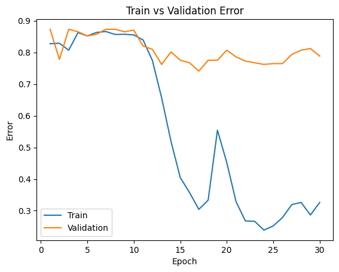

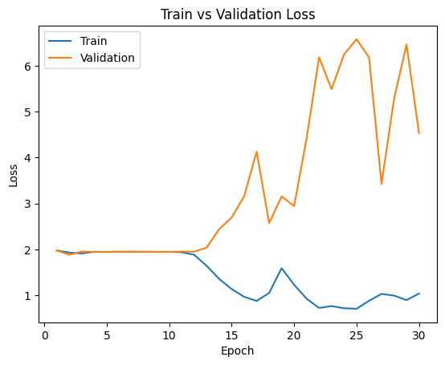

```python
# TO BE COMPLETED

# Reset the model to start with random weights
large_net = LargeNet()

# Train with higher learning rate
print("Training LargeNet with learning_rate=0.1")
train_net(large_net, learning_rate=0.1)

# Plot training curves
print("\nLargeNet (lr=0.1) Training Curves:")
model_path = get_model_name("large", batch_size=64, learning_rate=0.1, epoch=29)
model_path = os.path.join(save_dir, model_path)
plot_training_curve(model_path)
```

```python
'''
PROVIDE YOUR ANSWER BELOW

Now, when we set the learning rate to be .1, and we keep the model running on cuda GPU.

The training time (253.12 seconds) is shorter than the previous two conditions .
The previous conditions are lr=.01 with 260.73 seconds & lr=.001 with 271.12 seconds.

When we only comparing the learning rate and the time, it seems like that the larger the learning rate
and faster the training time. But the graphs here (lr=.1) show a clear unstable pattern.

For the first 10 epochs, both train and validation error stay very high (0.85) and the loss barely improves.
They all indicate poor progress.

After epoch 12, the training error drops sharply, but it it unstable, with spikes around epoch ~19–20.
It shows that updates are too large and the optimizer overshoots good solutions.
While validation error remains high (~0.75–0.87) with little consistent improvement, validation loss increases dramatically
and becomes highly volatile, reaching values over 6. This suggests
divergence rather than healthy learning.

Overall, the current condition with learning rate as 0.1 might be too large for the model,
so it leads to poor generalization and unstable training.


'''
```

### Part B-3(iii) [0.5pt EXPLORATORY]

Train `large_net` with all default parameters, including with `learning_rate=0.01`. Now, set `batch_size=512`. Does the model take longer/shorter to train? Plot the training curve. Describe the effect of *increasing* the batch size.

```
Training with batch_size=512
Using device: cuda
Epoch 1: Train err: 0.8651, Train loss: 1.9535 | Validation err: 0.8386, Validation loss: 1.9413
Epoch 2: Train err: 0.8618, Train loss: 1.9388 | Validation err: 0.8042, Validation loss: 1.9211
Epoch 3: Train err: 0.8512, Train loss: 1.9255 | Validation err: 0.8598, Validation loss: 1.9102
Epoch 4: Train err: 0.8532, Train loss: 1.9170 | Validation err: 0.8492, Validation loss: 1.8977
Epoch 5: Train err: 0.8089, Train loss: 1.8976 | Validation err: 0.7513, Validation loss: 1.8829
Epoch 6: Train err: 0.7321, Train loss: 1.8764 | Validation err: 0.7275, Validation loss: 1.8574
Epoch 7: Train err: 0.7063, Train loss: 1.8436 | Validation err: 0.7143, Validation loss: 1.8193
Epoch 8: Train err: 0.6892, Train loss: 1.7994 | Validation err: 0.6667, Validation loss: 1.7591
Epoch 9: Train err: 0.6396, Train loss: 1.7316 | Validation err: 0.6296, Validation loss: 1.6774
Epoch 10: Train err: 0.6250, Train loss: 1.6476 | Validation err: 0.6429, Validation loss: 1.6191
Epoch 11: Train err: 0.6224, Train loss: 1.6280 | Validation err: 0.6296, Validation loss: 1.6016
Epoch 12: Train err: 0.6171, Train loss: 1.6090 | Validation err: 0.6693, Validation loss: 1.7057
Epoch 13: Train err: 0.6243, Train loss: 1.6957 | Validation err: 0.6349, Validation loss: 1.5668
Epoch 14: Train err: 0.6528, Train loss: 1.5899 | Validation err: 0.6720, Validation loss: 1.6375
Epoch 15: Train err: 0.6270, Train loss: 1.5777 | Validation err: 0.6138, Validation loss: 1.6002
Epoch 16: Train err: 0.5873, Train loss: 1.5550 | Validation err: 0.6270, Validation loss: 1.5315
Epoch 17: Train err: 0.5721, Train loss: 1.4893 | Validation err: 0.5926, Validation loss: 1.4955
Epoch 18: Train err: 0.5516, Train loss: 1.4377 | Validation err: 0.5688, Validation loss: 1.4625
Epoch 19: Train err: 0.5317, Train loss: 1.4212 | Validation err: 0.5661, Validation loss: 1.4566
Epoch 20: Train err: 0.5198, Train loss: 1.3811 | Validation err: 0.5582, Validation loss: 1.4586
Epoch 21: Train err: 0.4921, Train loss: 1.3497 | Validation err: 0.5370, Validation loss: 1.4292
Epoch 22: Train err: 0.4907, Train loss: 1.3112 | Validation err: 0.5556, Validation loss: 1.4464
Epoch 23: Train err: 0.4735, Train loss: 1.2766 | Validation err: 0.5026, Validation loss: 1.3805
Epoch 24: Train err: 0.4577, Train loss: 1.2468 | Validation err: 0.5185, Validation loss: 1.3866
Epoch 25: Train err: 0.4530, Train loss: 1.2160 | Validation err: 0.4788, Validation loss: 1.3659
Epoch 26: Train err: 0.4239, Train loss: 1.1632 | Validation err: 0.4947, Validation loss: 1.3408
Epoch 27: Train err: 0.4114, Train loss: 1.1292 | Validation err: 0.4762, Validation loss: 1.3462
Epoch 28: Train err: 0.4028, Train loss: 1.1030 | Validation err: 0.4656, Validation loss: 1.3340
Epoch 29: Train err: 0.4028, Train loss: 1.0597 | Validation err: 0.4550, Validation loss: 1.3286
Epoch 30: Train err: 0.3823, Train loss: 1.0232 | Validation err: 0.5026, Validation loss: 1.3763
Finished Training
Total time elapsed: 263.79 seconds

LargeNet (batch_size=512) Training Curves:
```

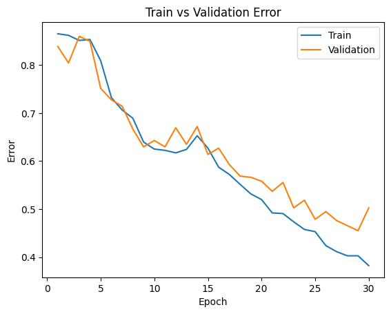

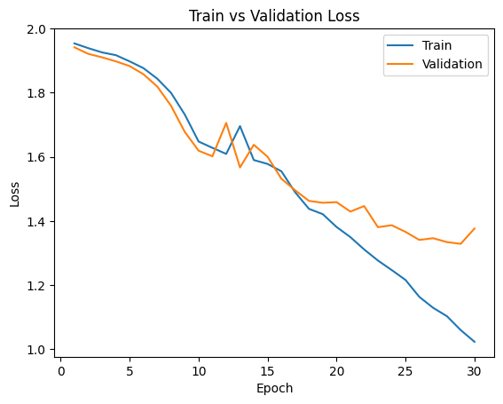

```python
# Reset the model to start with random weights
large_net = LargeNet()

# Train with larger batch size
print("Training with batch_size=512")
train_net(large_net, batch_size=512, learning_rate=0.01)

# Plot training curves
print("\nLargeNet (batch_size=512) Training Curves:")
model_path = get_model_name("large", batch_size=512, learning_rate=0.01, epoch=29)
model_path = os.path.join(save_dir, model_path)
plot_training_curve(model_path)
```

```python
'''
PROVIDE YOUR ANSWER BELOW


The current condition has batch_size as 512 and learning_rate as 0.01.
Comparing with the previous condition (lr=0.01. batch_size=64, time=260.73 seconds), the current training time is longer(263.79 seconds).

In the current condition, training becomes smoother and less noisy as we can see from the graph. Both training
and validation curves are much smoother with fewer fluctuations.

Also, the training error decreases much more slowly and remains relatively high (0.38 at epoch 30),
and training loss stays around ~1.02 rather than approaching 0.
Validation loss stays around ~1.33–1.38 instead of increasing sharply. This suggests better generalization.

Overall, a larger batch size gives more stable gradient estimates and reduces severe overfitting,
but it also reduces the number of updates per epoch; therefore, leading to slower improvement in training error/loss.




'''
```

### Part B-3(iv) [0.5pt EXPLORATORY]

Train `large_net` with all default parameters, including with `learning_rate=0.01`. Now, set `batch_size=16`. Does the model take longer/shorter to train? Plot the training curve. Describe the effect of *decreasing* the batch size.

```
Training with batch_size=16
Using device: cuda
Epoch 1: Train err: 0.7374, Train loss: 1.8442 | Validation err: 0.6772, Validation loss: 1.8026
Epoch 2: Train err: 0.6726, Train loss: 1.7301 | Validation err: 0.6799, Validation loss: 1.9059
Epoch 3: Train err: 0.7149, Train loss: 1.7747 | Validation err: 0.6958, Validation loss: 1.7100
Epoch 4: Train err: 0.6508, Train loss: 1.6764 | Validation err: 0.6481, Validation loss: 1.6564
Epoch 5: Train err: 0.5999, Train loss: 1.5447 | Validation err: 0.5926, Validation loss: 1.5080
Epoch 6: Train err: 0.5139, Train loss: 1.3723 | Validation err: 0.6085, Validation loss: 1.6856
Epoch 7: Train err: 0.4709, Train loss: 1.2752 | Validation err: 0.6164, Validation loss: 1.6009
Epoch 8: Train err: 0.3843, Train loss: 1.0589 | Validation err: 0.6561, Validation loss: 2.1573
Epoch 9: Train err: 0.3056, Train loss: 0.8573 | Validation err: 0.6005, Validation loss: 2.3272
Epoch 10: Train err: 0.2798, Train loss: 0.7789 | Validation err: 0.6164, Validation loss: 2.3540
Epoch 11: Train err: 0.2090, Train loss: 0.5907 | Validation err: 0.6376, Validation loss: 2.8179
Epoch 12: Train err: 0.1475, Train loss: 0.3985 | Validation err: 0.6296, Validation loss: 3.8969
Epoch 13: Train err: 0.1918, Train loss: 0.5842 | Validation err: 0.6164, Validation loss: 3.0157
Epoch 14: Train err: 0.1515, Train loss: 0.4804 | Validation err: 0.6349, Validation loss: 3.4307
Epoch 15: Train err: 0.1197, Train loss: 0.3615 | Validation err: 0.6164, Validation loss: 3.8828
Epoch 16: Train err: 0.1217, Train loss: 0.3511 | Validation err: 0.6190, Validation loss: 4.1068
Epoch 17: Train err: 0.1124, Train loss: 0.3413 | Validation err: 0.6323, Validation loss: 4.1797
Epoch 18: Train err: 0.1171, Train loss: 0.3626 | Validation err: 0.6296, Validation loss: 3.9115
Epoch 19: Train err: 0.0741, Train loss: 0.2411 | Validation err: 0.6481, Validation loss: 4.4029
Epoch 20: Train err: 0.0655, Train loss: 0.2094 | Validation err: 0.6058, Validation loss: 5.1418
Epoch 21: Train err: 0.0575, Train loss: 0.1884 | Validation err: 0.6587, Validation loss: 5.0447
Epoch 22: Train err: 0.0688, Train loss: 0.2225 | Validation err: 0.6164, Validation loss: 4.9389
Epoch 23: Train err: 0.0668, Train loss: 0.2096 | Validation err: 0.6190, Validation loss: 6.7772
Epoch 24: Train err: 0.0853, Train loss: 0.3266 | Validation err: 0.5952, Validation loss: 6.1707
Epoch 25: Train err: 0.0642, Train loss: 0.2377 | Validation err: 0.6138, Validation loss: 6.6774
Epoch 26: Train err: 0.1131, Train loss: 0.4638 | Validation err: 0.6825, Validation loss: 5.0988
Epoch 27: Train err: 0.0919, Train loss: 0.3069 | Validation err: 0.6640, Validation loss: 6.0804
Epoch 28: Train err: 0.0767, Train loss: 0.2686 | Validation err: 0.6217, Validation loss: 5.9821
Epoch 29: Train err: 0.0675, Train loss: 0.2475 | Validation err: 0.6376, Validation loss: 7.0236
Epoch 30: Train err: 0.0800, Train loss: 0.3121 | Validation err: 0.6587, Validation loss: 6.0520
Finished Training
Total time elapsed: 263.61 seconds

LargeNet (batch_size=16) Training Curves:
```

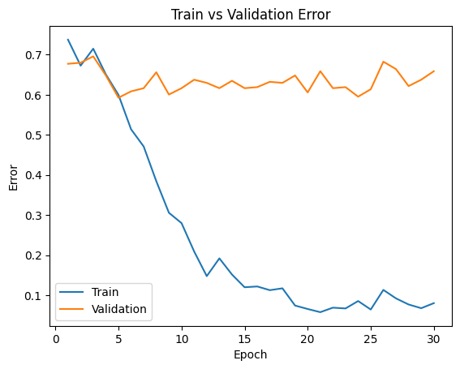

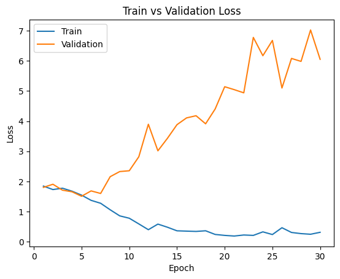

```python
# Reset the model to start with random weights
large_net = LargeNet()

# Train with smaller batch size
print("Training with batch_size=16")
train_net(large_net, batch_size=16, learning_rate=0.01)


# Plot training curves
print("\nLargeNet (batch_size=16) Training Curves:")
model_path = get_model_name("large", batch_size=16, learning_rate=0.01, epoch=29)
model_path = os.path.join(save_dir, model_path)
plot_training_curve(model_path)
```

```python
'''
PROVIDE YOUR ANSWER BELOW


The current condition has batch_size as 16 and learning_rate as 0.01.
Comparing with the previous condition (lr=0.01. batch_size=64, time=260.73 seconds),
the current training time is longer(263.61 seconds).

From the graph, the pattern is pretty similar as the all default condition, but there is a faster fitting to the training set.
Training error drops quickly and becomes very low (~0.08 by epoch 30), and training loss decreases to ~0.31.

In terms of validation error, it does not improve much and stays high (~0.60–0.66),
while validation loss increases dramatically and becomes extremely unstable,reaching values around 6–7 by later epochs.


If we comparing the current condition with the previous one condition(batch_size=512, time=263.79 seconds), the current condition has a shorter training time.
The previous one shows smooth curves and small train–val gap), batch_size=16 shows much larger train–val gap and highly unstable validation loss

Overall, decreasing batch size makes training updates noisier and increases overfitting and instability in this experiment.



'''
```

## Part B-4. Hyperparameter Search

### Part B-4(i) [0.5pt EXPLORATORY]

Based on the plots from above, choose another set of values for the hyperparameters (network, batch_size, learning_rate) that you think would help you improve the validation accuracy. Justify your choice.

```python
'''
PROVIDE YOUR ANSWER BELOW


Based on the previous experiments, I would choose:

- LargeNet,
- batch_size=512,
- learning_rate=0.001.


From the previous experiments, LargeNet has higher capacity than SmallNet and achieves lower training
error, so it is less likely to underfit.

However, with the default hyperparameters (batch_size=64,lr=0.01), the model clearly overfits.
Training error goes to 0 while validation error becomes stable and validation loss increases sharply.

Increasing batch_size to 512 produced a much smaller train–validation gap and a much more stable
validation loss. This can improve generalization. Lowering the learning rate to 0.001 also stabilized training
and reduced the dramatic increase in validation loss seen with lr=0.01.

Therefore, combining these two changes (larger batch + smaller lr) should reduce overfitting
and make optimization more stable, which is likely to improve validation accuracy.


'''
```

### Part B-4(ii) [0.5pt EXPLORATORY]

Train the model with the hyperparameters you chose in part(i), and include the training curve.

```
Training chosen model (LargeNet, batch_size=512, learning_rate=0.001)...
Using device: cuda
Epoch 1: Train err: 0.8856, Train loss: 1.9510 | Validation err: 0.8730, Validation loss: 1.9472
Epoch 2: Train err: 0.8869, Train loss: 1.9505 | Validation err: 0.8783, Validation loss: 1.9466
Epoch 3: Train err: 0.8816, Train loss: 1.9498 | Validation err: 0.8704, Validation loss: 1.9457
Epoch 4: Train err: 0.8717, Train loss: 1.9488 | Validation err: 0.8519, Validation loss: 1.9447
Epoch 5: Train err: 0.8591, Train loss: 1.9477 | Validation err: 0.8598, Validation loss: 1.9437
Epoch 6: Train err: 0.8419, Train loss: 1.9466 | Validation err: 0.8598, Validation loss: 1.9426
Epoch 7: Train err: 0.8327, Train loss: 1.9455 | Validation err: 0.8413, Validation loss: 1.9417
Epoch 8: Train err: 0.8313, Train loss: 1.9445 | Validation err: 0.8280, Validation loss: 1.9408
Epoch 9: Train err: 0.8234, Train loss: 1.9436 | Validation err: 0.8254, Validation loss: 1.9398
Epoch 10: Train err: 0.8142, Train loss: 1.9426 | Validation err: 0.8148, Validation loss: 1.9388
Epoch 11: Train err: 0.8022, Train loss: 1.9416 | Validation err: 0.8095, Validation loss: 1.9377
Epoch 12: Train err: 0.7950, Train loss: 1.9406 | Validation err: 0.8042, Validation loss: 1.9367
Epoch 13: Train err: 0.7943, Train loss: 1.9394 | Validation err: 0.7937, Validation loss: 1.9356
Epoch 14: Train err: 0.7890, Train loss: 1.9383 | Validation err: 0.7831, Validation loss: 1.9344
Epoch 15: Train err: 0.7864, Train loss: 1.9371 | Validation err: 0.7778, Validation loss: 1.9332
Epoch 16: Train err: 0.7778, Train loss: 1.9360 | Validation err: 0.7778, Validation loss: 1.9318
Epoch 17: Train err: 0.7811, Train loss: 1.9348 | Validation err: 0.7831, Validation loss: 1.9305
Epoch 18: Train err: 0.7804, Train loss: 1.9335 | Validation err: 0.7778, Validation loss: 1.9290
Epoch 19: Train err: 0.7804, Train loss: 1.9319 | Validation err: 0.7804, Validation loss: 1.9274
Epoch 20: Train err: 0.7824, Train loss: 1.9304 | Validation err: 0.7804, Validation loss: 1.9257
Epoch 21: Train err: 0.7791, Train loss: 1.9288 | Validation err: 0.7857, Validation loss: 1.9239
Epoch 22: Train err: 0.7778, Train loss: 1.9271 | Validation err: 0.7884, Validation loss: 1.9220
Epoch 23: Train err: 0.7765, Train loss: 1.9253 | Validation err: 0.7884, Validation loss: 1.9200
Epoch 24: Train err: 0.7771, Train loss: 1.9234 | Validation err: 0.7910, Validation loss: 1.9178
Epoch 25: Train err: 0.7784, Train loss: 1.9212 | Validation err: 0.7910, Validation loss: 1.9154
Epoch 26: Train err: 0.7791, Train loss: 1.9191 | Validation err: 0.7910, Validation loss: 1.9129
Epoch 27: Train err: 0.7778, Train loss: 1.9165 | Validation err: 0.7937, Validation loss: 1.9101
Epoch 28: Train err: 0.7771, Train loss: 1.9140 | Validation err: 0.7937, Validation loss: 1.9072
Epoch 29: Train err: 0.7765, Train loss: 1.9113 | Validation err: 0.7884, Validation loss: 1.9041
Epoch 30: Train err: 0.7771, Train loss: 1.9083 | Validation err: 0.7937, Validation loss: 1.9007
Finished Training
Total time elapsed: 255.80 seconds

Chosen hyperparameters training curves:
```

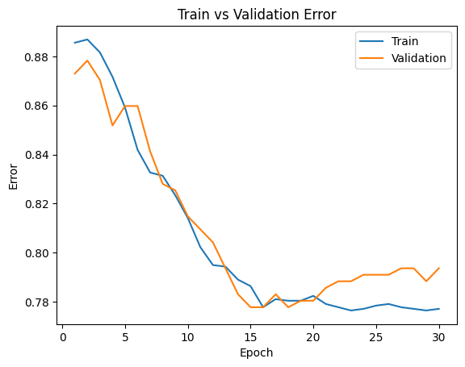

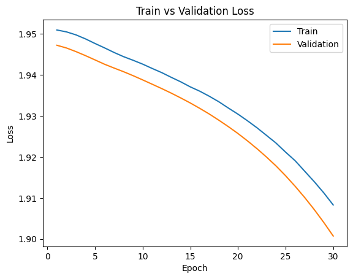

```python
# TO BE COMPLETED

# Mount Google Drive (if using Colab)
from google.colab import drive
drive.mount('/content/drive')

# 1) Train the chosen model with your selected hyperparameters
print("Training chosen model (LargeNet, batch_size=512, learning_rate=0.001)...")
trained_net = train_net(large_net, batch_size=512, learning_rate=0.001, num_epochs=30, save_dir=save_dir)

# 2) Plot the training curves for the run above
print("\nChosen hyperparameters training curves:")
model_path = get_model_name("large", batch_size=512, learning_rate=0.001, epoch=29)
model_path = os.path.join(save_dir, model_path)
plot_training_curve(model_path)
```